# Progress Memo 1

Final Project  
Data Science 1 with R (STAT 301-1)

Author

Fiona Liu

Published

November 7, 2025

**TipGithub Repo Link**

[Fiona’s Github](https://github.com/stat301-1-2025-fall/final-project-1-fionaliu0105)

## Data source

The dataset for this project is a collection of affective (emotional) norms for 13,915 English words, known as lemmas.[^1]

<sup>1</sup> Warriner, A. B., Kuperman, V., & Brysbaert, M. (2013). Norms of valence, arousal, and dominance for 13,915 English lemmas. *Behavior Research Methods, 45*(4), 1191–1207. https://doi.org/10.3758/s13428-012-0314-x.

**Source URL:** https://link.springer.com/article/10.3758/s13428-012-0314-x, located in the “Electronic supplementary material”.

This data was collected via large-scale crowdsourcing, where participants rated each word on three distinct emotional dimensions:

- **Valence:** The pleasantness of the word (from negative/unpleasant to positive/pleasant).
- **Arousal:** The intensity of the emotion evoked (from calm/subdued to excited/energized).
- **Dominance:** The sense of control associated with the word (from submissive/controlled to dominant/in-control).

### Why this data

I am interested in a cognitive science dataset, and this one is a good fit for an Exploratory Data Analysis (EDA). It directly relates to my interest in how humans process language and memory.

The data’s structure is simple, clean, and well-documented, making it perfect for applying the data manipulation (`dplyr`) and visualization (`ggplot2`) skills from STAT 301-1. It allows for a meaningful analysis of linguistic patterns without requiring the complex machine learning or modeling techniques that are outside the scope of this course.

## Data quality & complexity check

The dataset is of high quality and low complexity.

A complete dictionary of the variables selected for analysis is provided in Table 1.

Table 1: Data Dictionary: Key Variables for Analysis

| Variable | Original Type | Description |
| --- | --- | --- |
| `Word` | chr | The English lemma (word) rated by participants |
| `V.Mean.Sum` | dbl | Mean Valence rating (overall across all participants) |
| `A.Mean.Sum` | dbl | Mean Arousal rating (overall across all participants) |
| `D.Mean.Sum` | dbl | Mean Dominance rating (overall across all participants) |
| `V.SD.Sum` | dbl | Standard deviation of all Valence ratings for this word |
| `A.SD.Sum` | dbl | Standard deviation of all Arousal ratings for this word |
| `D.SD.Sum` | dbl | Standard deviation of all Dominance ratings for this word |
| `V.Mean.M` / `V.Mean.F` | dbl | Mean Valence ratings split by male (M) and female (F) participants |

A summary of these three numeric dimensions was generated using `dplyr::summarize()` and is shown in Table 2. As the table indicates, there are no missing (`NA`) values in the key data columns.

Table 2: Summary Statistics for Key Affective Dimensions

| Dimension | Mean | Std. Dev. | Min | Max | Missing |
| --- | --- | --- | --- | --- | --- |
| Valence | 5.06 | 1.27 | 1.26 | 8.53 | 0 |
| Arousal | 4.21 | 0.90 | 1.60 | 7.79 | 0 |
| Dominance | 5.18 | 0.94 | 1.68 | 7.90 | 0 |

The preliminary plot in Figure 1 shows the distribution of valence scores. It appears to be roughly normal, centered around a neutral score of 5.

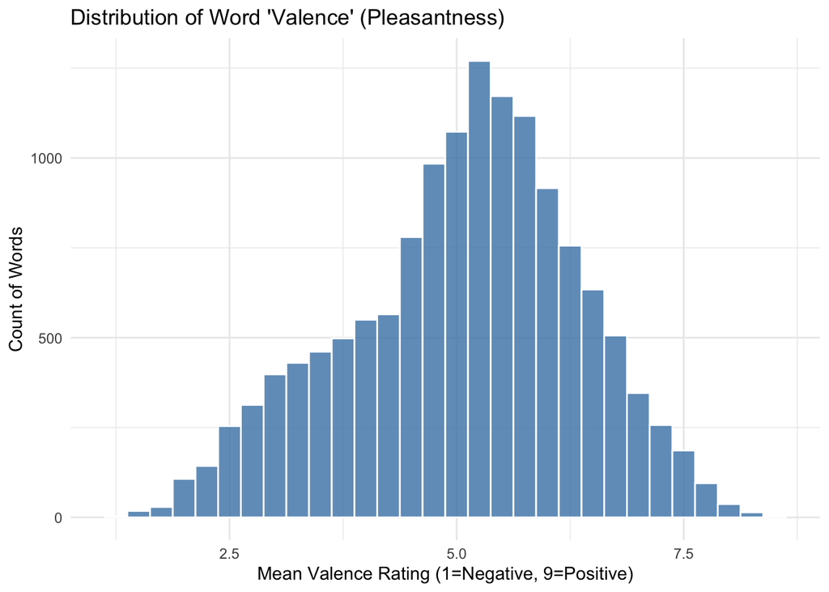

Figure 1: Distribution of Mean Valence Scores (V.Mean.Sum) for 13,915 English Words

## Potential data issues

This dataset is pre-cleaned and standardized, so no significant data cleaning is anticipated. The main “challenge” will not be cleaning data but rather exploring it effectively.

The primary task will be to use functions from `dplyr` to filter and summarize the 13,915 words to answer interesting questions (e.g., “What are the 10 most positive-valence words?” or “How does arousal relate to valence?”). The analysis will focus on data exploration and visualization rather than data wrangling.

## Analysis Plan

My proposed analysis plan includes:

- **1. Univariate Analysis:** I will first explore the shape of the three main dimensions. This involves:
  - Plotting histograms for `Valence`, `Arousal`, and `Dominance` to examine their distributions.
  - Calculating summary statistics and using `dplyr::slice_max()` and `slice_min()` to find the top/bottom 10 most extreme words for each dimension.
- **2. Bivariate Analysis:** The core of the analysis will be exploring the relationships *between* the dimensions.
  - I will plot `Valence` vs. `Arousal` (using `geom_point` and `geom_smooth`) to find the “U-shaped” relationship, which shows that both very positive and very negative words are highly arousing.
  - I will also plot `Valence` vs. `Dominance` to show their linear relationship.
- **3. Group Difference Analysis:** I will explore the demographic data by comparing the `V.Mean.M` (Male) and `V.Mean.F` (Female) columns.
  - I plan to create scatter plots comparing male and female ratings directly, using `geom_abline` to show the line of equality.
  - I will also `filter()` for specific “taboo” or “weapon” words (as mentioned in the paper) to see if I can replicate the finding that males rate these words as more positive and in-control. (str_detect)
- **4. Variability Analysis:** I will analyze rating *agreement* by plotting the mean scores (e.g., `V.Mean.Sum`) against their standard deviations (`V.SD.Sum`) to see if neutral words are indeed the most “ambiguous” (have the highest standard deviation).
- **5. Linguistic Comparison (Verb vs. Noun suffixes)**: I plan to use `stringr` functions taught in class, specifically `str_detect()`, to identify words with common noun suffixes (e.g., ending in “-tion”, “-ment”) versus common verb suffixes (e.g., ending in “-ize”, “-ate”). I will then compare the emotional ratings of these two groups to see if grammatical form relates to valence or arousal.